# Activity: Cell annotation with Azimuth

2026-08-22

# Option 1: Mapping to a tissue-specific dataset

## Step 1: Download reference dataset

In this example, we will analyze the kidney query dataset again using Azimuth. That means we need a kidney reference dataset, which we can find on the Azimuth website: https://azimuth.hubmapconsortium.org/references/#Human%20-%20Kidney.

Download the reference data from the Zenodo link: https://zenodo.org/records/10694842 Save both files (ref.rds and idx.annoy) in a directory.

## Step 2: Load the query dataset

Load the kidney sample and process the data so that we can conduct reference mapping

```r
library(zellkonverter)
library(Seurat)
# Read HBM764.ZCQR.585
query <- readH5AD("../02_exercise/kidney_query_dataset/expr_HBM764.ZCQR.585_kidney.h5ad")
```

```
## For native R and reading and writing of H5AD files, an R <AnnData> object, and
## conversion to <SingleCellExperiment> or <Seurat> objects, check out the
## anndataR package:
## ℹ Install it from Bioconductor with `BiocManager::install("anndataR")`
## ℹ See more at <https://bioconductor.org/packages/anndataR/>
```

```r
query_seurat <- as.Seurat(query, counts = "X", data = "X")
```

```r
library(org.Hs.eg.db)
# Convert assay name to "RNA"
query_seurat <- RenameAssays(object = query_seurat, originalexp = "RNA")
```

```
## Renaming default assay from originalexp to RNA
```

```r
# Convert feature names from Ensembl to gene symbols
ensembl_ids <- rownames(query_seurat[["RNA"]])
ensembl_ids <- gsub("\\..*", "", ensembl_ids)
gene_symbols <- mapIds(
  org.Hs.eg.db,
  keys = ensembl_ids,
  keytype = "ENSEMBL",
  column = "SYMBOL",
  multiVals = "first"
)
gene_symbols[is.na(gene_symbols)] <- ensembl_ids[is.na(gene_symbols)]
gene_symbols <- make.unique(gene_symbols)

# Add the new gene symbols back to the Seurat object
counts_mat <- GetAssayData(query_seurat, layer = "counts")
data_mat   <- GetAssayData(query_seurat, layer = "data")
rownames(counts_mat) <- gene_symbols
rownames(data_mat)   <- gene_symbols
query_seurat[["RNA"]] <- CreateAssayObject(counts = counts_mat)
query_seurat <- SetAssayData(query_seurat, layer = "data", new.data = data_mat)
```

```r
query_seurat$nFeature_RNA <- colSums(query_seurat[["RNA"]]$counts > 0)
query_seurat$nCount_RNA <- Matrix::colSums(query_seurat[["RNA"]]$counts)
query_seurat[["percent.mt"]] <- PercentageFeatureSet(query_seurat, pattern = "^MT-")
head(query_seurat)
```

```
##                     orig.ident nCount_originalexp nFeature_originalexp
## AAAACACTCTTTACGC SeuratProject             2.0000                    1
## AAACCCACACACTTAG SeuratProject           594.5986                  551
## AAACCCATCAAGGACG SeuratProject           926.2060                  781
## AAACCCATCTCCCTAG SeuratProject           610.2500                  525
## AAACGAACATGACGTT SeuratProject          1522.3068                 1200
## AAACGAAGTCTGTGCG SeuratProject           498.5716                  355
## AAACGCTCAGAGTCTT SeuratProject           528.5833                  487
## AAACGCTGTAGATTAG SeuratProject           613.1556                  582
## AAACGCTGTCCAAATC SeuratProject           446.5333                  452
## AAAGAACAGTTCAACC SeuratProject           426.4000                  408
##                  nCount_RNA nFeature_RNA percent.mt
## AAAACACTCTTTACGC     2.0000            1   0.000000
## AAACCCACACACTTAG   594.5986          551   6.020868
## AAACCCATCAAGGACG   926.2060          781   1.727477
## AAACCCATCTCCCTAG   610.2500          525   4.752151
## AAACGAACATGACGTT  1522.3068         1200   4.243427
## AAACGAAGTCTGTGCG   498.5716          355   3.810887
## AAACGCTCAGAGTCTT   528.5833          487   1.702664
## AAACGCTGTAGATTAG   613.1556          582   2.512544
## AAACGCTGTCCAAATC   446.5333          452   6.270529
## AAAGAACAGTTCAACC   426.4000          408   1.641651
```

```r
# VlnPlot(query_seurat, features = c("nFeature_RNA", "nCount_RNA", "percent.mt"), ncol = 3)
query_seurat <- subset(query_seurat, subset = nFeature_RNA > 200 & percent.mt < 25)
dim(query_seurat)
```

```
## [1] 60286  2690
```

```r
query_seurat <- NormalizeData(query_seurat)
```

## Step 3: Use Azimuth to reference map onto the kidney reference

```r
query_azimuth <- Azimuth::RunAzimuth(query_seurat, "azimuth_kidney_ref/")
```

```
## Attaching shinyBS
```

```
## detected inputs from HUMAN with id type Gene.name
```

```
## reference rownames detected HUMAN with id type Gene.name
```

```
## Normalizing query using reference SCT model
```

```
## Only one SCT model detected; no need to select.
```

```
## Projecting cell embeddings
```

```
## Finding query neighbors
```

```
## Finding neighborhoods
```

```
## Finding anchors
```

```
##  Found 2201 anchors
```

```
## Finding integration vectors
```

```
## Finding integration vector weights
```

```
## Predicting cell labels
## Predicting cell labels
## Predicting cell labels
```

```
##
## Integrating dataset 2 with reference dataset
```

```
## Finding integration vectors
```

```
## Integrating data
```

```
## Running UMAP projection
```

```
## 16:14:21 Processing block 1 of 1
```

```
## 16:14:22 Finished
```

```
## Projecting reference PCA onto query
## Finding integration vector weights
## Projecting back the query cells into original PCA space
## Finding integration vector weights
## Computing scores:
##     Finding neighbors of original query cells
##     Finding neighbors of transformed query cells
##     Computing query SNN
##     Determining bandwidth and computing transition probabilities
## Total elapsed time: 1.48396611213684
```

Let’s inspect our output. The new Seurat object contains additional metadata columns containing cell type annotations at various levels of resolution:

```r
head(query_azimuth[[]])
```

```
##                     orig.ident nCount_originalexp nFeature_originalexp
## AAACCCACACACTTAG SeuratProject           594.5986                  551
## AAACCCATCAAGGACG SeuratProject           926.2060                  781
## AAACCCATCTCCCTAG SeuratProject           610.2500                  525
## AAACGAACATGACGTT SeuratProject          1522.3068                 1200
## AAACGAAGTCTGTGCG SeuratProject           498.5716                  355
## AAACGCTCAGAGTCTT SeuratProject           528.5833                  487
##                  nCount_RNA nFeature_RNA percent.mt
## AAACCCACACACTTAG   594.5986          551   6.020868
## AAACCCATCAAGGACG   926.2060          781   1.727477
## AAACCCATCTCCCTAG   610.2500          525   4.752151
## AAACGAACATGACGTT  1522.3068         1200   4.243427
## AAACGAAGTCTGTGCG   498.5716          355   3.810887
## AAACGCTCAGAGTCTT   528.5833          487   1.702664
##                  predicted.annotation.l1.score predicted.annotation.l1
## AAACCCACACACTTAG                     0.9335195    Thick Ascending Limb
## AAACCCATCAAGGACG                     0.9925344             Endothelial
## AAACCCATCTCCCTAG                     0.9870429    Thick Ascending Limb
## AAACGAACATGACGTT                     0.9928757             Endothelial
## AAACGAAGTCTGTGCG                     0.8233368    Descending Thin Limb
## AAACGCTCAGAGTCTT                     1.0000000              Fibroblast
##                  predicted.annotation.l2.score          predicted.annotation.l2
## AAACCCACACACTTAG                     0.7216407   Medullary Thick Ascending Limb
## AAACCCATCAAGGACG                     0.8526028 Ascending Vasa Recta Endothelial
## AAACCCATCTCCCTAG                     0.8033336   Medullary Thick Ascending Limb
## AAACGAACATGACGTT                     0.6921693 Ascending Vasa Recta Endothelial
## AAACGAAGTCTGTGCG                     0.6273099      Descending Thin Limb Type 1
## AAACGCTCAGAGTCTT                     0.8062192             Medullary Fibroblast
##                  predicted.annotation.l3.score          predicted.annotation.l3
## AAACCCACACACTTAG                     0.7216407   Medullary Thick Ascending Limb
## AAACCCATCAAGGACG                     0.8526028 Ascending Vasa Recta Endothelial
## AAACCCATCTCCCTAG                     0.8033336   Medullary Thick Ascending Limb
## AAACGAACATGACGTT                     0.6921693 Ascending Vasa Recta Endothelial
## AAACGAAGTCTGTGCG                     0.6273099      Descending Thin Limb Type 1
## AAACGCTCAGAGTCTT                     0.8062192             Medullary Fibroblast
##                  mapping.score
## AAACCCACACACTTAG     0.8932482
## AAACCCATCAAGGACG     0.8787667
## AAACCCATCTCCCTAG     0.8783685
## AAACGAACATGACGTT     0.8431339
## AAACGAAGTCTGTGCG     0.7939006
## AAACGCTCAGAGTCTT     0.8915750
```

We can take a preliminary look at the distribution of cells across predicted cell types.

```r
head(sort(table(query_azimuth[["predicted.annotation.l1"]]), decreasing = T))
```

```
## predicted.annotation.l1
## Thick Ascending Limb Descending Thin Limb           Fibroblast
##                 1361                  448                  277
##          Endothelial            Principal               Immune
##                  242                  129                   69
```

```r
head(sort(table(query_azimuth[["predicted.annotation.l2"]]), decreasing = T))
```

```
## predicted.annotation.l2
##   Medullary Thick Ascending Limb    Cortical Thick Ascending Limb
##                              851                              464
##      Descending Thin Limb Type 1             Medullary Fibroblast
##                              349                              271
## Ascending Vasa Recta Endothelial      Descending Thin Limb Type 2
##                              137                               90
```

```r
head(sort(table(query_azimuth[["predicted.annotation.l3"]]), decreasing = T))
```

```
## predicted.annotation.l3
##   Medullary Thick Ascending Limb    Cortical Thick Ascending Limb
##                              853                              464
##      Descending Thin Limb Type 1             Medullary Fibroblast
##                              351                              271
## Ascending Vasa Recta Endothelial      Descending Thin Limb Type 2
##                              137                               90
```

We can also visualize the predicted cell types on the reference dataset’s UMAP:

[figure not shown]

```r
DimPlot(query_azimuth, reduction = "ref.umap", group.by = "predicted.annotation.l2")
```

We can also build a new UMAP just based on the query cells.

```r
query_azimuth <- FindVariableFeatures(query_azimuth)
query_azimuth <- ScaleData(query_azimuth)
query_azimuth <- RunPCA(query_azimuth, features = VariableFeatures(object = query_azimuth))
```

```
## PC_ 1
## Positive:  EGFL7, ENG, PODXL, NHERF2, IFI27, EMCN, PECAM1, BST2, PLVAP, PTPRB
##     IGFBP4, A2M, RNASE1, RGCC, VIM, FN1, SOX18, TEK, HYAL2, CD34
##     SPARC, FLT1, PLAT, EPAS1, TM4SF1, NOTCH4, SLC14A1, RAMP2, MMRN2, GSN
## Negative:  SLC12A1, UMOD, ATP1A1, MUC1, CLU, DEFB1, CYFIP2, AQP2, ENSG00000236283, ATP6V0A4
##     WFDC2, AQP3, MMP7, AOC1, FXYD4, GATA3, PERP, SPTBN2, LHX1, SLC14A2
##     SLC26A7, KRT19, TSPAN1, LAMC2, SLC12A3, SLPI, S100A2, SCNN1G, ID4, PIK3C2G
## PC_ 2
## Positive:  EGFL7, IFI27, PODXL, PTPRB, RNASE1, PECAM1, PLVAP, RGCC, CD34, NOTCH4
##     MMRN2, SOX18, FLT1, TEK, NHERF2, RAMP2, FN1, SLC14A1, CDH5, BST2
##     KDR, FAM167B, CAVIN2, TM4SF1, CLEC14A, KLF2, ADGRF5, DNASE1L3, PDE2A, FABP5
## Negative:  C7, DCN, IGF2, MGP, BGN, LTBP1, ENSG00000284779, ADH1B, LUM, COL12A1
##     AEBP1, PDGFRA, COL14A1, COL1A2, MOXD1, H19, FBLN1, NPY1R, VCAN, CCN2
##     CA8, C1R, PDGFRB, SFRP1, A2M, CALD1, IGFBP5, S1PR3, TNC, EDNRB
## PC_ 3
## Positive:  AQP3, AQP2, FXYD4, TSPAN1, MMP7, SPTBN2, LHX1, GATA3, ENSG00000236283, MUC1
##     AOC1, KRT19, SCNN1G, STC1, PIK3C2G, CLU, UGT3A1, WFDC2, PTGER1, PTGS1
##     SLC26A7, KCTD12, AQP6, SLC52A3, SCNN1B, ATP6V0A4, S100A2, CNGA1, RHCG, SLC4A1
## Negative:  SLC12A1, UMOD, DEFB1, STAB1, ATP1A1, FN1, FABP5, SFRP1, FLRT2, ST8SIA6
##     PLAT, DNASE1L3, ENSG00000267423, ZCCHC24, TLL1, PTPRC, MS4A7, SEMA3D, CYFIP2, MS4A6A
##     TRPM2, PDE2A, PCDHGB6, ENG, C6orf141, TMC8, ALX1, COL3A1, PLVAP, FMO2
## PC_ 4
## Positive:  SLC26A7, AQP6, RHCG, SLC4A1, ENSG00000249601, KIT, CALCA, EXOSC7, FOXI1, ATP6V0D2
##     CLEC3B, ATP6V0A4, RHBG, HEPACAM2, STAP1, ATP6V1G3, SPARCL1, SLC4A9, PLAT, RGCC
##     DNASE1L3, PCDH7, FN1, FLRT2, HCAR1, PLVAP, SEMA3D, ENSG00000267423, COL3A1, SPTBN2
## Negative:  AQP1, SEMA3G, FBLN2, ADAMTS6, ADAMTS1, CLDN5, AQP2, CCN3, STC1, ENPP2
##     KRT19, LHX1, SLC14A1, CD36, PALMD, AOC1, FXYD4, CLU, MMP7, CD53
##     SLC4A11, AQP3, ITIH5, SPOCK2, SCNN1G, TPM1, PTGER1, RNF144B, SRGN, UGT3A1
## PC_ 5
## Positive:  SEMA3G, FBLN2, CLDN5, SLC26A7, ENPP2, ADAMTS6, AQP1, EFNB2, AQP6, RHCG
##     PALMD, SLC14A1, ITIH5, SLC4A1, ADAMTS1, RBP7, CD36, ENSG00000249601, EXOSC7, CD53
##     KIT, CALCA, FOXI1, GPIHBP1, GJA5, BTNL9, CLEC3B, SOX17, SPARCL1, CD93
## Negative:  PLAT, DNASE1L3, FN1, FLRT2, PLVAP, SEMA3D, ENSG00000267423, COL3A1, AQP2, TEK
##     RGCC, FAM167B, IGFBP4, LHX1, ST8SIA6, SH3BP5, FXYD4, AQP3, ZCCHC24, KRT19
##     TLL1, AOC1, SNCG, FABP5, RNASE1, GBP4, STAB1, SELP, SCNN1G, ENG
```

```r
query_azimuth <- RunUMAP(query_azimuth, 1:20)
```

We can color this UMAP by the predicted cell types.

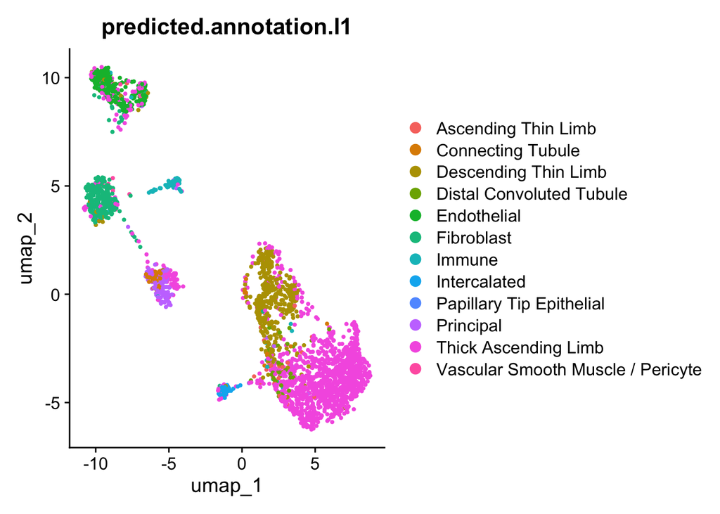

```r
UMAPPlot(query_azimuth, group.by = "predicted.annotation.l1")
```

# Option 2: Mapping to a pan-human reference dataset

Instead of using a kidney-specific dataset, we can use Azimuth’s cloud interface to map cells from a query dataset to a pan-human reference comprised of cells from more than 20 human tissues (including kidney).

```r
library(AzimuthAPI)
query_cloud <- CloudAzimuth(query_seurat)
```

```
## ── Running Pan-human Azimuth on the cloud ──────────────────────────────────────
```

```
## ℹ Uploading dataset...
```

```
## ℹ Uploading file and listening for updates...
```

```
## ✔ File successfully uploaded.
```

```
## Activating environment 'CloudAnnotate'...
```

```
## Environment 'CloudAnnotate' is now active.
```

```
## ── panhumanpy version: 1.0.0 ──
```

```
## Parsing command line arguments...
```

```
## Formatting arguments for ANNotate function...
```

```
## Cloud_ANNotate_R is being executed from the command line...
```

```
## Reading Seurat object from
## /tmp/cloudazimuth/25946e70-92c5-48a5-b422-6f324172374e/file7ba95517c4c6.rds
```

```
## Running ANNotate function...
```

```
## Running Pan-human Azimuth:
```

```
## ── Reference model and parameters: ──
```

```
## Model version: v1
```

```
## Model name: M0.2
```

```
## Evaluation batch size: 8192
```

```
## Extract embeddings: True
```

```
## Run umap: False
```

```
## Refine labels in postprocessing: True
```

```
## Map to Cell Ontology columns: None
```

```
## Include CL ID: False
```

```
## Integer counts detected by panhumanpy.ANNotate : False
```

```
## Log-normalization performed by panhumanpy.ANNotate: False
```

```
## Query object:
```

```
## Total number of cells: 2690
```

```
## Total number of features: 4836
```

[output not shown]

```
## Splitting query data into 1 evaluation batch(es) of up to
```

```
## 8192 cells.
```

```
## Interpreting label predictions for consistent granularity at broad, medium,
## fine level(s).
```

```
## ── Running model: ──
```

[output not shown]

[output not shown]

[output not shown]

[output not shown]

[output not shown]

[output not shown]

[output not shown]

[output not shown]

[output not shown]

[output not shown]

[output not shown]

[output not shown]

[output not shown]

```
## Extracting azimuth embeddings:
```

[output not shown]

[output not shown]

[output not shown]

[output not shown]

[output not shown]

[output not shown]

[output not shown]

[output not shown]

```
## Saving annotated object to
## /tmp/cloudazimuth/25946e70-92c5-48a5-b422-6f324172374e/file7ba95517c4c6_ANN.rds
```

```
## ✔ ANNotate_R completed successfully.
```

```
## An object of class Seurat
```

```
## 4836 features across 2690 samples within 1 assay
```

```
## Active assay: RNA (4836 features, 0 variable features)
```

```
## 1 layer present: data
```

```
## 1 dimensional reduction calculated: azimuth_embed
```

```
## ✔ R script finished successfully
```

```
## ℹ Output file ready for download
```

```
## 25946e70-92c5-48a5-b422-6f324172374e/file7ba95517c4c6_ANN.rds
```

```
## ℹ Downloading the output file...
```

```
## ✔ Annotation complete. Output saved to: /var/folders/lf/w1qk9j8571z4tm2tnkxpc8lw0000gq/T//RtmpCURS5m/file7ba95517c4c6_ANN.rds
```

The metadata contains predicted cell types at different resolutions, along with confidence metrics.

```r
head(query_cloud[[]])
```

```
##                  orig.ident nCount_originalexp nFeature_originalexp nCount_RNA
## AAACCCACACACTTAG          1           594.5986                  551   594.5986
## AAACCCATCAAGGACG          1           926.2060                  781   926.2060
## AAACCCATCTCCCTAG          1           610.2500                  525   610.2500
## AAACGAACATGACGTT          1          1522.3068                 1200  1522.3068
## AAACGAAGTCTGTGCG          1           498.5716                  355   498.5716
## AAACGCTCAGAGTCTT          1           528.5833                  487   528.5833
##                  nFeature_RNA percent.mt
## AAACCCACACACTTAG          551   6.020868
## AAACCCATCAAGGACG          781   1.727477
## AAACCCATCTCCCTAG          525   4.752151
## AAACGAACATGACGTT         1200   4.243427
## AAACGAAGTCTGTGCG          355   3.810887
## AAACGCTCAGAGTCTT          487   1.702664
##                                                                                              full_hierarchical_labels
## AAACCCACACACTTAG                      Epithelial cell|Epithelial cell of kidney|Renal epithelial cell - Loop of Henle
## AAACCCATCAAGGACG                                                                            Epithelial cell|Venous EC
## AAACCCATCTCCCTAG Immune cell|Epithelial cell of kidney|Renal epithelial cell - Loop of Henle|Type B intercalated cell
## AAACGAACATGACGTT                                                                         Endothelial cell|Arterial EC
## AAACGAAGTCTGTGCG                   Epithelial cell|Epithelial cell of kidney|Renal epithelial cell - proximal tubules
## AAACGCTCAGAGTCTT                                                                                           Fibroblast
##                                        final_level_labels
## AAACCCACACACTTAG    Renal epithelial cell - Loop of Henle
## AAACCCATCAAGGACG                                Venous EC
## AAACCCATCTCCCTAG                 Type B intercalated cell
## AAACGAACATGACGTT                              Arterial EC
## AAACGAAGTCTGTGCG Renal epithelial cell - proximal tubules
## AAACGCTCAGAGTCTT                               Fibroblast
##                  final_level_confidence full_consistent_hierarchy
## AAACCCACACACTTAG              0.9356617                      TRUE
## AAACCCATCAAGGACG              0.8283184                     FALSE
## AAACCCATCTCCCTAG              0.1168406                     FALSE
## AAACGAACATGACGTT              0.9110795                      TRUE
## AAACGAAGTCTGTGCG              0.5124211                      TRUE
## AAACGCTCAGAGTCTT              0.9835734                      TRUE
##                     azimuth_broad                           azimuth_medium
## AAACCCACACACTTAG  Epithelial cell    Renal epithelial cell - Loop of Henle
## AAACCCATCAAGGACG            False                                    False
## AAACCCATCTCCCTAG            False                                    False
## AAACGAACATGACGTT Endothelial cell                         Endothelial cell
## AAACGAAGTCTGTGCG  Epithelial cell Renal epithelial cell - proximal tubules
## AAACGCTCAGAGTCTT       Fibroblast                               Fibroblast
##                                              azimuth_fine
## AAACCCACACACTTAG    Renal epithelial cell - Loop of Henle
## AAACCCATCAAGGACG                                    False
## AAACCCATCTCCCTAG                                    False
## AAACGAACATGACGTT                              Arterial EC
## AAACGAAGTCTGTGCG Renal epithelial cell - proximal tubules
## AAACGCTCAGAGTCTT                      CFD+MGP+ fibroblast
##                                             azimuth_label
## AAACCCACACACTTAG    Renal epithelial cell - Loop of Henle
## AAACCCATCAAGGACG                                Venous EC
## AAACCCATCTCCCTAG                 Type B intercalated cell
## AAACGAACATGACGTT                              Arterial EC
## AAACGAAGTCTGTGCG Renal epithelial cell - proximal tubules
## AAACGCTCAGAGTCTT                               Fibroblast
```

Let’s inspect the predicted cell type annotations for this version of the output:

```r
head(sort(table(query_cloud[["final_level_labels"]]), decreasing = T))
```

```
## final_level_labels
##  Renal epithelial cell - Loop of Henle Renal epithelial cell - distal tubules
##                                   1250                                    277
##                             Fibroblast                            Plasma cell
##                                    187                                    127
##                              Venous EC               Type B intercalated cell
##                                    120                                    101
```